# **Plants Seedling Classification**

### **Context:**

In recent times, the field of agriculture has been in urgent need of modernizing, since the amount of manual work people need to put in to check if plants are growing correctly is still highly extensive. Despite several advances in agricultural technology, people working in the agricultural industry still need to have the ability to sort and recognize different plants and weeds, which takes a lot of time and effort in the long term.

The potential is ripe for this trillion-dollar industry to be greatly impacted by technological innovations that cut down on the requirement for manual labor, and this is where Artificial Intelligence can benefit the workers in this field, *as the time and energy required to identify plant seedlings will be greatly shortened by the use of AI and Deep Learning.* The ability to do so far more efficiently and even more effectively than experienced manual labor could lead to better crop yields, the freeing up of human involvement for higher-order agricultural decision making, and in the long term will result in more sustainable environmental practices in agriculture as well.

### **Objective:**

The Aarhus University Signal Processing group, in collaboration with the University of Southern Denmark, has provided the data containing images of unique plants belonging to 12 different species. You being a data scientist, need to build a Convolutional Neural Network model which would classify the plant seedlings into their respective 12 categories.

### **Data Description:**

This dataset contains images of unique plants belonging to 12 different species.  
The data file names are:

- images.npy
- Label.csv  
  Due to the large volume of data, the images were converted to numpy arrays and stored in images.npy file and the corresponding labels are also put into Labels.csv so that you can work on the data/project seamlessly without having to worry about the high data volume.  
  The goal of the project is to create a classifier capable of determining a plant's species from an image.  
  ##List of Plant species##
- Black-grass
- Charlock
- Cleavers
- Common Chickweed
- Common Wheat
- Fat Hen
- Loose Silky-bent
- Maize
- Scentless Mayweed
- Shepherds Purse
- Small-flowered Cranesbill
- Sugar beet

#### **Note: Please use GPU runtime to execute the code efficiently**

Before running this notebook, go to  
Edit -> Notebook settings -> Hardware accelerator  
Change it to GPU. This will speed up the code.

## **Importing the necessary libraries**

```python
import os
import numpy as np                                                                               # Importing numpy for Matrix Operations
import pandas as pd                                                                              # Importing pandas to read CSV files
import matplotlib.pyplot as plt                                                                  # Importting matplotlib for Plotting and visualizing images
import math                                                                                      # Importing math module to perform mathematical operations
import cv2                                                                                       # Importing openCV for image processing
import seaborn as sns                                                                            # Importing seaborn to plot graphs
import random

# Tensorflow modules
import tensorflow as tf
from tensorflow.keras.preprocessing.image import ImageDataGenerator                              # Importing the ImageDataGenerator for data augmentation
from tensorflow.keras.models import Sequential                                                   # Importing the sequential module to define a sequential model
from tensorflow.keras.layers import Dense,Dropout,Flatten,Conv2D,MaxPooling2D,BatchNormalization # Defining all the layers to build our CNN Model
from tensorflow.keras.optimizers import Adam,SGD                                                 # Importing the optimizers which can be used in our model
from sklearn import preprocessing                                                                # Importing the preprocessing module to preprocess the data
from sklearn.model_selection import train_test_split                                             # Importing train_test_split function to split the data into train and test
from sklearn.metrics import confusion_matrix                                                     # Importing confusion_matrix to plot the confusion matrix
from sklearn.utils import class_weight
from sklearn.preprocessing import LabelBinarizer
from sklearn.model_selection import train_test_split
from sklearn.metrics import classification_report
from tensorflow.keras import backend

# Display images using OpenCV
from google.colab.patches import cv2_imshow                                                      # Importing cv2_imshow from google.patches to display images

from tensorflow.keras.models import Model
from keras.applications.vgg16 import VGG16

# Ignore warnings
import warnings
warnings.filterwarnings('ignore')
```

```python
# Check if running on GPU and print an appropriate message for information.
if int(os.environ["COLAB_GPU"]) > 0:
  print("Running on a GPU")
else:
  print("Not running on a GPU")
```

```
Running on a GPU
```

## **Reading the dataset**

```python
# Mount Google drive to access the dataset (monkeys_dataset.zip)
from google.colab import drive
drive.mount('/content/drive')

# Load the image file of the dataset
images = np.load('/content/drive/MyDrive/cv_proj/images.npy')

# Load the labels file of the dataset
labels = pd.read_csv('/content/drive/MyDrive/cv_proj/Labels.csv')
```

## **Overview of the dataset**

Let's print the shape of the images and labels

```python
print(images.shape)
print(labels.shape)
print('\n\nThere are', labels.shape[0],'RGB images of shape', images.shape[1], 'X', images.shape[2], 'X', images.shape[3],', each image having', images.shape[3],'channels.')
print('There are',len(set(labels['Label'])),'distinct labels.')
```

```
(4750, 128, 128, 3)
(4750, 1)


There are 4750 RGB images of shape 128 X 128 X 3 , each image having 3 channels.
There are 12 distinct labels.
```

## Plotting images using OpenCV and matplotlib

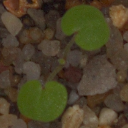

```python
cv2_imshow(images[5])
```

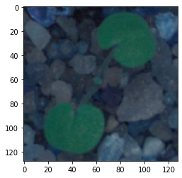

```python
plt.imshow(images[5])
```

- We can observe that the images are being shown in different colors when plotted with openCV and matplotlib as OpenCV reads images in BGR format and this shows that the given numpy arrays were generated from the original images using OpenCV.
- Now we will convert these BGR images to RGB images so we could interpret them easily.

```python
# Converting the images from BGR to RGB using cvtColor function of OpenCV
for i in range(len(images)):
  images[i] = cv2.cvtColor(images[i], cv2.COLOR_BGR2RGB)
```

## **Exploratory Data Analysis**

```python
np.random.seed(1) #for numpy
random.seed(1)
tf.random.set_seed(1) #for tensorflow
```

```python
def plot_images(images,labels):
  num_classes=len(set(labels['Label']))                                                                 # Number of Classes
  categories=np.unique(labels)
  keys = labels['Label']                                                                 # Obtaing the unique classes from y_train
  rows = 3                                                                        # Defining number of rows=3
  cols = 4                                                                        # Defining number of columns=4
  fig = plt.figure(figsize=(12, 10))                                               # Defining the figure size to 10x8
  for i in range(cols):
      for j in range(rows):
          random_index = np.random.randint(0, len(labels))                        # Generating random indices from the data and plotting the images
          ax = fig.add_subplot(rows, cols, i * rows + j + 1)                      # Adding subplots with 3 rows and 4 columns
          ax.imshow(images[random_index, :])                                      # Plotting the image
          ax.set_title(keys[random_index])
          #print(random_index,i,j,i * rows + j + 1)
  plt.show()
```

[figure not shown]

```python
plot_images(images,labels)
```

- The above code uses randint and doesn't guarantee that we view an image of each class. You may see multiple images of the same class. Let's write a new code to ensure that.

```python
def plot_images_improved(images,labels):
  """
  The code iterates through each training image. If that class hasn't been displayed already, it displays it.
  It stops when it has shown an image of each class.
  """

  num_classes=len(set(labels['Label']))
  rows = 3                                                                        # Defining number of rows=3
  cols = 4                                                                        # Defining number of columns=4
  categories=np.unique(labels)
  keys=dict(labels['Label'])
  # Obtaing the unique classes from y_train
  uniq_keys = set(keys.values())
  used_keys=set()
  fig = plt.figure(figsize=(12, 12))
  plots_so_far = 0
  curr_row = 0
  curr_col = 0
  while(len(used_keys) < num_classes):
    if not (keys[plots_so_far] in used_keys):
      used_keys.add(keys[plots_so_far])
      ax = fig.add_subplot(rows, cols, curr_col * rows + curr_row + 1)
      ax.imshow(images[plots_so_far, :])
      ax.set_title(keys[plots_so_far])
      curr_col = curr_col+1
      if(curr_col == cols):
        curr_col = 0
        curr_row = curr_row+1
    plots_so_far = plots_so_far+1
  plt.show()
```

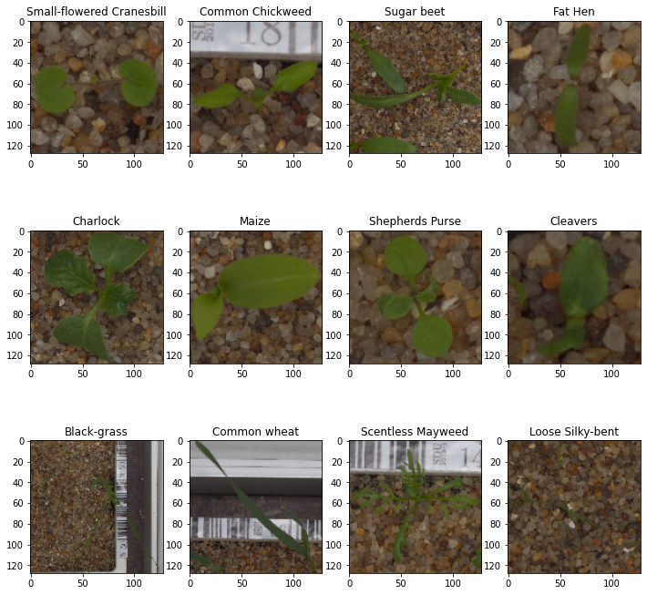

```python
plot_images_improved(images,labels)
```

- With the above code, we were able to see an image of each of the 12 classes available.

**Checking for data imbalance**

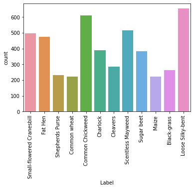

```python
 sns.countplot(labels['Label']);
 plt.xticks(rotation='vertical');
```

```python
# Storing the value counts of target variable
count=labels['Label'].value_counts()
print(count)
print('*'*10)
count=100*labels['Label'].value_counts(normalize=True)
print(count)
```

```
Loose Silky-bent             654
Common Chickweed             611
Scentless Mayweed            516
Small-flowered Cranesbill    496
Fat Hen                      475
Charlock                     390
Sugar beet                   385
Cleavers                     287
Black-grass                  263
Shepherds Purse              231
Common wheat                 221
Maize                        221
Name: Label, dtype: int64
**********
Loose Silky-bent             13.768421
Common Chickweed             12.863158
Scentless Mayweed            10.863158
Small-flowered Cranesbill    10.442105
Fat Hen                      10.000000
Charlock                      8.210526
Sugar beet                    8.105263
Cleavers                      6.042105
Black-grass                   5.536842
Shepherds Purse               4.863158
Common wheat                  4.652632
Maize                         4.652632
Name: Label, dtype: float64
```

- As you can see from the above plot, the dataset is rather imbalanced.
- The class member count varies between 220 and 650.
- We make a note of this imbalance here and relook at it later after checking the accuracy if necessary.

## **Observations**

- There are 12 different class labels in the dataset.
- Loose Silky-bent is the most common member in the dataset and Common wheat is the least common member class.
- Maize and Cleavers appear rather similar in appearance. It is likely to be difficulty to tell them apart. Their performance in the confusion matrix will be interesting to watch.
- Images have extraneous objects apart from the plant such as pebbles, paper with writings. Image recognition will have to overcome any deleterious effects of this noise.
- Some images have the plant taking most of the size, whereas in other images, the plant takes up a small part of the size.
- Not all plants are oriented the same way. Enhancing the training dataset by rotating at different angles is likely to be useful.

### Resizing images

As the size of the images is large, it may be computationally expensive to train on these larger images; therefore, it is preferable to reduce the image size from 128 to 64.

```python
images_decreased=[]
height = 64
width = 64
dimensions = (width, height)
for i in range(len(images)):
  images_decreased.append( cv2.resize(images[i], dimensions, interpolation=cv2.INTER_LINEAR))
```

- Let's view the same image that we saw earlier.

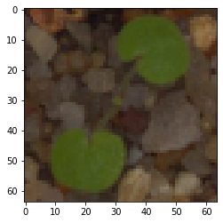

```python
plt.imshow(images_decreased[5])
```

## Visualizing images using Gaussian Blur

```python
# Applying Gaussian Blur to denoise the images
images_gb=[]
for i in range(len(images)):
  # gb[i] = cv2.cvtColor(images[i], cv2.COLOR_BGR2RGB)
  images_gb.append(cv2.GaussianBlur(images[i], ksize =(3,3),sigmaX =  0))
```

- Let's view the same image we viewed earlier.

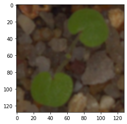

```python
plt.imshow(images_gb[5])
```

- It appears that GaussianBlur would be ineffective because the blurred or denoised image does not seem to have denoised by much, and the model would struggle to categorize these blurred images. We will keep an eye on the accuracy and use this set only if necessary.

## **Splitting the dataset**

- As we have only a few images in our dataset, we will only use 10% of our data for testing, 10% of our data for validation and 80% of our data for training.
- We are using the train_test_split() function from scikit-learn. Here, we split the dataset into three parts, train,test and validation.

```python
# training, test and validation split
X_temp, X_test, y_temp, y_test = train_test_split(np.array(images_decreased),labels , test_size=0.1, random_state=42,stratify=labels)
X_train, X_val, y_train, y_val = train_test_split(X_temp,y_temp , test_size=0.1, random_state=42,stratify=y_temp)
```

- Let's look at the size of each of the train, test and validation datasets.

```python
print(X_train.shape,y_train.shape)
print(X_val.shape,y_val.shape)
print(X_test.shape,y_test.shape)
```

```
(3847, 64, 64, 3) (3847, 1)
(428, 64, 64, 3) (428, 1)
(475, 64, 64, 3) (475, 1)
```

- The sizes look as expected.

## **Let's compute and store the class weights that we may use later**

```python
labelList = labels.Label.unique()
class_weights = class_weight.compute_class_weight(class_weight = "balanced",
                                                  classes = np.array(labelList),
                                                  y = y_train.values.reshape(-1)
                                                  )
class_weights = dict(zip(np.array(range(len(labelList))), class_weights))
#print calculated class weights
class_weights
```

```
{0: 0.7974709784411277,
 1: 0.8348524305555556,
 2: 1.714349376114082,
 3: 1.7909683426443204,
 4: 0.6476430976430977,
 5: 1.0145042194092826,
 6: 1.3818247126436782,
 7: 0.7669457735247209,
 8: 1.0275106837606838,
 9: 1.7909683426443204,
 10: 1.5050860719874803,
 11: 0.604874213836478}
```

## **Making the data compatible:**

- Convert labels from names to one hot vectors
- Normalizing the values

```python
# Convert labels from names to one hot vectors.
# We will be using a encoding method called labelBinarizer.
# Labelbinarizer works similar to onehotencoder

enc = LabelBinarizer()
y_train_encoded = enc.fit_transform(y_train)
y_val_encoded=enc.transform(y_val)
y_test_encoded=enc.transform(y_test)
```

## Data Normalization

Since the **image pixel values range from 0-255**, our method of normalization here will be **scaling** - we shall **divide all the pixel values by 255 to standardize the images to have values between 0-1.**

```python
# Normalizing the image pixels
X_train_normalized = X_train.astype('float32')/255.0
X_val_normalized = X_val.astype('float32')/255.0
X_test_normalized = X_test.astype('float32')/255.0
```

## Choice of Metric to optimize

Both precision and recall are important in this case study. There is no strong reason to favor one over the other. Hence, we will optimize for **accuracy** (f1 metric would be an equally valid choice). Note that, while there is imbalance in classes, it's not 1:10. Hence even the less frequent class will be covered by accuracy. If the imbalance was more than 1:10, "recall" would have been more appropriate choice because we wouldn't want to miss out on the less frequent classes. Also, we will display all metrics for all models. This will help assess the model performance holistically.

## **Model Building - Convolutional Neural Network (CNN)**

Let's create a CNN model sequentially, where we will be adding the layers one after another.

First, we need to clear the previous model's history from the session even if a single model can run multiple times on the same data.

In Keras, we need a special command to clear the model's history, otherwise the previous model history remains in the backend.

Also, let's fix the seed again after clearing the backend.

Let's **set the seed for random number generators in Numpy, the Random library in Python, and in TensorFlow** to be able to reproduce the same results every time we run the code.

```python
# Clearing backend
backend.clear_session()
```

```python
# Fixing the seed for random number generators
np.random.seed(1) #for numpy
random.seed(1)
tf.random.set_seed(1) #for tensorflow
```

Now, let's build a **CNN Model** with the following 2 main parts -

1. **The Feature Extraction layers** which are comprised of convolutional and pooling layers.
2. **The Fully Connected classification layers** for prediction.

```python
# Intializing a sequential model
model = Sequential()

# Adding first conv layer with 64 filters and kernel size 3x3 , padding 'same' provides the output size same as the input size
# Input_shape denotes input image dimension of images
model.add(Conv2D(64, (3, 3), activation='relu', padding="same", input_shape=(64, 64, 3)))

# Adding max pooling to reduce the size of output of first conv layer
model.add(MaxPooling2D((2, 2), padding = 'same'))

model.add(Conv2D(32, (3, 3), activation='relu', padding="same"))
model.add(MaxPooling2D((2, 2), padding = 'same'))

# flattening the output of the conv layer after max pooling to make it ready for creating dense connections
model.add(Flatten())

# Adding a fully connected dense layer with 100 neurons
model.add(Dense(16, activation='relu'))
#model.add(Dropout(0.3))
# Adding the output layer with 12 neurons and activation functions as softmax since this is a multi-class classification problem
model.add(Dense(12, activation='softmax'))

# Using SGD Optimizer
# opt = SGD(learning_rate=0.01, momentum=0.9)
opt=Adam()
# Compile model
model.compile(optimizer=opt, loss='categorical_crossentropy', metrics=['accuracy'])

# Generating the summary of the model
model.summary()
```

```
Model: "sequential"
_________________________________________________________________
 Layer (type)                Output Shape              Param #
=================================================================
 conv2d (Conv2D)             (None, 64, 64, 64)        1792

 max_pooling2d (MaxPooling2D  (None, 32, 32, 64)       0
 )

 conv2d_1 (Conv2D)           (None, 32, 32, 32)        18464

 max_pooling2d_1 (MaxPooling  (None, 16, 16, 32)       0
 2D)

 flatten (Flatten)           (None, 8192)              0

 dense (Dense)               (None, 16)                131088

 dense_1 (Dense)             (None, 12)                204

=================================================================
Total params: 151,548
Trainable params: 151,548
Non-trainable params: 0
_________________________________________________________________
```

### **Fitting the model on the train data**

```python
history_1 = model.fit(
            X_train_normalized, y_train_encoded,
            epochs=30,
            validation_data=(X_val_normalized,y_val_encoded),
            batch_size=32,
            verbose=2
)
```

```
121/121 - 2s - loss: 2.3781 - accuracy: 0.1952 - val_loss: 2.2130 - val_accuracy: 0.3341 - 2s/epoch - 14ms/step
121/121 - 1s - loss: 2.0321 - accuracy: 0.3410 - val_loss: 1.8998 - val_accuracy: 0.3738 - 887ms/epoch - 7ms/step
121/121 - 1s - loss: 1.8060 - accuracy: 0.3886 - val_loss: 1.7693 - val_accuracy: 0.4393 - 876ms/epoch - 7ms/step
121/121 - 1s - loss: 1.6641 - accuracy: 0.4247 - val_loss: 1.6258 - val_accuracy: 0.4416 - 801ms/epoch - 7ms/step
121/121 - 1s - loss: 1.5762 - accuracy: 0.4484 - val_loss: 1.6049 - val_accuracy: 0.4439 - 753ms/epoch - 6ms/step
121/121 - 1s - loss: 1.4882 - accuracy: 0.4718 - val_loss: 1.6028 - val_accuracy: 0.4696 - 770ms/epoch - 6ms/step
121/121 - 1s - loss: 1.4421 - accuracy: 0.4879 - val_loss: 1.4704 - val_accuracy: 0.4883 - 762ms/epoch - 6ms/step
121/121 - 1s - loss: 1.3853 - accuracy: 0.5051 - val_loss: 1.4604 - val_accuracy: 0.4930 - 765ms/epoch - 6ms/step
121/121 - 1s - loss: 1.3430 - accuracy: 0.5149 - val_loss: 1.4203 - val_accuracy: 0.5164 - 764ms/epoch - 6ms/step
121/121 - 1s - loss: 1.2677 - accuracy: 0.5454 - val_loss: 1.3881 - val_accuracy: 0.5257 - 750ms/epoch - 6ms/step
121/121 - 1s - loss: 1.1970 - accuracy: 0.5706 - val_loss: 1.3288 - val_accuracy: 0.5724 - 757ms/epoch - 6ms/step
121/121 - 1s - loss: 1.0926 - accuracy: 0.6257 - val_loss: 1.2838 - val_accuracy: 0.5794 - 761ms/epoch - 6ms/step
121/121 - 1s - loss: 0.9591 - accuracy: 0.6701 - val_loss: 1.1769 - val_accuracy: 0.6145 - 787ms/epoch - 7ms/step
121/121 - 1s - loss: 0.8771 - accuracy: 0.7005 - val_loss: 1.3011 - val_accuracy: 0.5841 - 969ms/epoch - 8ms/step
121/121 - 1s - loss: 0.8318 - accuracy: 0.7159 - val_loss: 1.2702 - val_accuracy: 0.6028 - 884ms/epoch - 7ms/step
121/121 - 1s - loss: 0.7530 - accuracy: 0.7502 - val_loss: 1.1624 - val_accuracy: 0.6379 - 865ms/epoch - 7ms/step
121/121 - 1s - loss: 0.6940 - accuracy: 0.7642 - val_loss: 1.1446 - val_accuracy: 0.6565 - 845ms/epoch - 7ms/step
121/121 - 1s - loss: 0.6493 - accuracy: 0.7871 - val_loss: 1.1750 - val_accuracy: 0.6565 - 763ms/epoch - 6ms/step
121/121 - 1s - loss: 0.6199 - accuracy: 0.7954 - val_loss: 1.1608 - val_accuracy: 0.6519 - 776ms/epoch - 6ms/step
121/121 - 1s - loss: 0.5558 - accuracy: 0.8196 - val_loss: 1.2288 - val_accuracy: 0.6612 - 773ms/epoch - 6ms/step
121/121 - 1s - loss: 0.5450 - accuracy: 0.8256 - val_loss: 1.1916 - val_accuracy: 0.6659 - 751ms/epoch - 6ms/step
121/121 - 1s - loss: 0.4904 - accuracy: 0.8487 - val_loss: 1.2183 - val_accuracy: 0.6869 - 776ms/epoch - 6ms/step
121/121 - 1s - loss: 0.4653 - accuracy: 0.8542 - val_loss: 1.3100 - val_accuracy: 0.6472 - 751ms/epoch - 6ms/step
121/121 - 1s - loss: 0.4351 - accuracy: 0.8656 - val_loss: 1.3379 - val_accuracy: 0.6752 - 767ms/epoch - 6ms/step
121/121 - 1s - loss: 0.4331 - accuracy: 0.8622 - val_loss: 1.3494 - val_accuracy: 0.6565 - 762ms/epoch - 6ms/step
121/121 - 1s - loss: 0.3823 - accuracy: 0.8846 - val_loss: 1.3935 - val_accuracy: 0.6449 - 757ms/epoch - 6ms/step
121/121 - 1s - loss: 0.3498 - accuracy: 0.8973 - val_loss: 1.5192 - val_accuracy: 0.6215 - 891ms/epoch - 7ms/step
121/121 - 1s - loss: 0.3554 - accuracy: 0.8926 - val_loss: 1.5460 - val_accuracy: 0.6519 - 855ms/epoch - 7ms/step
121/121 - 1s - loss: 0.3145 - accuracy: 0.9054 - val_loss: 1.6343 - val_accuracy: 0.6075 - 890ms/epoch - 7ms/step
121/121 - 1s - loss: 0.2834 - accuracy: 0.9173 - val_loss: 1.7401 - val_accuracy: 0.6145 - 972ms/epoch - 8ms/step
```

### **Model Evaluation**

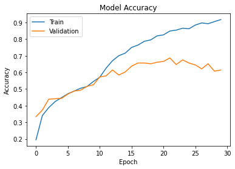

```python
plt.plot(history_1.history['accuracy'])
plt.plot(history_1.history['val_accuracy'])
plt.title('Model Accuracy')
plt.ylabel('Accuracy')
plt.xlabel('Epoch')
plt.legend(['Train', 'Validation'], loc='upper left')
plt.show()
```

**Observations:**

### **Generating the predictions using test data**

```python
accuracy = model.evaluate(X_test_normalized, y_test_encoded, verbose=2)
```

```
15/15 - 0s - loss: 1.6273 - accuracy: 0.6211 - 76ms/epoch - 5ms/step
```

```python
# Here we would get the output as probablities for each category
y_pred=model.predict(X_test_normalized)
```

### **Plotting the Confusion Matrix**

- The Confusion matrix is also defined as an inbuilt function in the TensorFlow module, so we can use that for evaluating the classification model.
- The Confusion matrix expects categorical data as input. However, y_test_encoded is an encoded value, whereas y_pred has probabilities. So,we must retrieve the categorical values from the encoded values.
- We will use the `argmax()` function to obtain the maximum value over each category on both y_test_encoded and y_pred and obtain their respective classes.

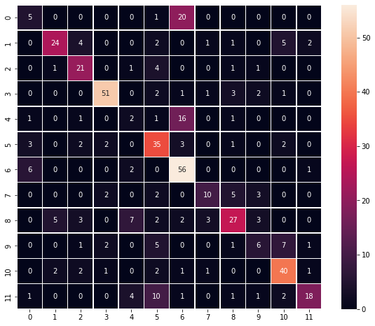

```python
# Obtaining the categorical values from y_test_encoded and y_pred
y_pred_arg=np.argmax(y_pred,axis=1)
y_test_arg=np.argmax(y_test_encoded,axis=1)

# Plotting the Confusion Matrix using confusion matrix() function which is also predefined tensorflow module
confusion_matrix = tf.math.confusion_matrix(y_test_arg,y_pred_arg)
f, ax = plt.subplots(figsize=(10, 8))
sns.heatmap(
    confusion_matrix,
    annot=True,
    linewidths=.4,
    fmt="d",
    square=True,
    ax=ax
)
plt.show()
```

```python
print(classification_report((y_test_arg), y_pred_arg))
```

```
              precision    recall  f1-score   support

           0       0.31      0.19      0.24        26
           1       0.75      0.62      0.68        39
           2       0.62      0.72      0.67        29
           3       0.88      0.84      0.86        61
           4       0.12      0.09      0.11        22
           5       0.53      0.73      0.61        48
           6       0.56      0.86      0.68        65
           7       0.62      0.45      0.53        22
           8       0.66      0.52      0.58        52
           9       0.38      0.26      0.31        23
          10       0.70      0.80      0.75        50
          11       0.78      0.47      0.59        38

    accuracy                           0.62       475
   macro avg       0.58      0.55      0.55       475
weighted avg       0.62      0.62      0.61       475
```

**Observations**

# Model-2

As we can see, our initial model appears to not do a good job of predicting the class from the image. Therefore we'll try to address this problem with data augmentation and Batch Normalization to check if we can improve the model's performance.

## **Data Augmentation**

In most of the real-world case studies, it is challenging to acquire a large number of images and then train CNNs. To overcome this problem, one approach we might consider is **Data Augmentation**. CNNs have the property of **translational invariance**, which means they can recognise an object even if its appearance shifts translationally in some way.  
Taking this attribute into account, we can augment the images using the techniques listed below -  
**1. Horizontal Flip** (should be set to True/False)  
**2. Vertical Flip** (should be set to True/False)  
**3. Height Shift** (should be between 0 and 1)  
**4. Width Shift** (should be between 0 and 1)  
**5. Rotation** (should be between 0 and 180)  
**6. Shear** (should be between 0 and 1)  
**7. Zoom** (should be between 0 and 1) etc.

**Data augmentation should not be used in the validation/test data set**.

```python
# Clearing backend
backend.clear_session()

# Fixing the seed for random number generators
np.random.seed(1)
random.seed(1)
tf.random.set_seed(1)
```

```python
# All images to be rescaled by 1/255.
train_datagen = ImageDataGenerator(
                              rotation_range=20,
                              fill_mode='nearest'
                              )
# test_datagen  = ImageDataGenerator(rescale = 1.0/255.)
```

```python
# Intializing a sequential model
model = Sequential()

# Adding first conv layer with 64 filters and kernel size 3x3 , padding 'same' provides the output size same as the input size
# Input_shape denotes input image dimension of images
model.add(Conv2D(64, (3, 3), activation='relu', padding="same", input_shape=(64, 64, 3)))

# Adding max pooling to reduce the size of output of first conv layer
model.add(MaxPooling2D((2, 2), padding = 'same'))

model.add(Conv2D(32, (3, 3), activation='relu', padding="same"))
model.add(MaxPooling2D((2, 2), padding = 'same'))

# flattening the output of the conv layer after max pooling to make it ready for creating dense connections
model.add(Flatten())

# Adding a fully connected dense layer with 100 neurons
model.add(Dense(16, activation='relu'))
# Adding the output layer with 12 neurons and activation functions as softmax since this is a multi-class classification problem
model.add(Dense(12, activation='softmax'))

# Using SGD Optimizer
# opt = SGD(learning_rate=0.01, momentum=0.9)
opt=Adam()
# Compile model
model.compile(optimizer=opt, loss='categorical_crossentropy', metrics=['accuracy'])

# Generating the summary of the model
model.summary()
```

```
Model: "sequential"
_________________________________________________________________
 Layer (type)                Output Shape              Param #
=================================================================
 conv2d (Conv2D)             (None, 64, 64, 64)        1792

 max_pooling2d (MaxPooling2D  (None, 32, 32, 64)       0
 )

 conv2d_1 (Conv2D)           (None, 32, 32, 32)        18464

 max_pooling2d_1 (MaxPooling  (None, 16, 16, 32)       0
 2D)

 flatten (Flatten)           (None, 8192)              0

 dense (Dense)               (None, 16)                131088

 dense_1 (Dense)             (None, 12)                204

=================================================================
Total params: 151,548
Trainable params: 151,548
Non-trainable params: 0
_________________________________________________________________
```

```python
# Epochs
epochs = 25
# Batch size
batch_size = 64

history = model.fit(train_datagen.flow(X_train_normalized,y_train_encoded,
                                       batch_size=batch_size,
                                       seed=1,
                                       shuffle=False),
                    epochs=epochs,
                    steps_per_epoch=X_train_normalized.shape[0] // batch_size,
                    validation_data=(X_val_normalized,y_val_encoded),
                    verbose=1)
```

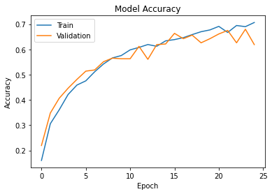

```python
plt.plot(history.history['accuracy'])
plt.plot(history.history['val_accuracy'])
plt.title('Model Accuracy')
plt.ylabel('Accuracy')
plt.xlabel('Epoch')
plt.legend(['Train', 'Validation'], loc='upper left')
plt.show()
```

```python
accuracy = model.evaluate(X_test_normalized, y_test_encoded, verbose=2)
```

```
15/15 - 0s - loss: 1.1088 - accuracy: 0.6232 - 75ms/epoch - 5ms/step
```

We can observe that our accuracy has improved compared to our previous model, but only by a little. We will try other options.

```python
# Here we would get the output as probablities for each category
y_pred=model.predict(X_test_normalized)
```

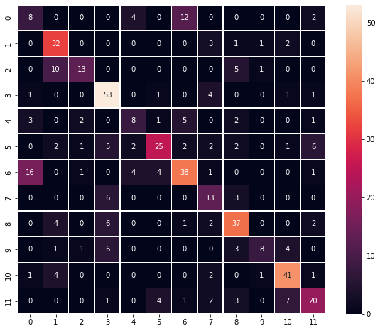

```python
# Obtaining the categorical values from y_test_encoded and y_pred
y_pred_arg=np.argmax(y_pred,axis=1)
y_test_arg=np.argmax(y_test_encoded,axis=1)

# Plotting the Confusion Matrix using confusion matrix() function which is also predefined tensorflow module
confusion_matrix = tf.math.confusion_matrix(y_test_arg,y_pred_arg)
f, ax = plt.subplots(figsize=(10, 8))
sns.heatmap(
    confusion_matrix,
    annot=True,
    linewidths=.4,
    fmt="d",
    square=True,
    ax=ax
)
plt.show()
```

```python
print(classification_report((y_test_arg), y_pred_arg))
```

```
              precision    recall  f1-score   support

           0       0.28      0.31      0.29        26
           1       0.60      0.82      0.70        39
           2       0.72      0.45      0.55        29
           3       0.69      0.87      0.77        61
           4       0.44      0.36      0.40        22
           5       0.71      0.52      0.60        48
           6       0.64      0.58      0.61        65
           7       0.45      0.59      0.51        22
           8       0.66      0.71      0.69        52
           9       0.73      0.35      0.47        23
          10       0.73      0.82      0.77        50
          11       0.59      0.53      0.56        38

    accuracy                           0.62       475
   macro avg       0.60      0.58      0.58       475
weighted avg       0.63      0.62      0.62       475
```

**Observation:**

- The confusion matrix appears to be improving marginally, however there is still some confusion with the 0,4,6 and 11 classes.
- The 0th class is the most confused class among all.
- We can observe that this model has outperformed by a small amount as compared to our previous model.

# Model-3

As we can see, our initial models appears to not do a good job of predicting the class from the image. Therefore we'll try to address this problem with Batch Normalization and Dropout to check if we can improve the model's performance.

```python
# Clearing backend
backend.clear_session()

# Fixing the seed for random number generators
np.random.seed(1)
random.seed(1)
tf.random.set_seed(1)
```

```python
# Intializing a sequential model
model = Sequential()

# Adding first conv layer with 64 filters and kernel size 3x3 , padding 'same' provides the output size same as the input size
# Input_shape denotes input image dimension images
model.add(Conv2D(64, (3, 3), activation='relu', padding="same", input_shape=(64, 64, 3)))

# Adding max pooling to reduce the size of output of first conv layer
model.add(MaxPooling2D((2, 2), padding = 'same'))
# model.add(BatchNormalization())
model.add(Conv2D(32, (3, 3), activation='relu', padding="same"))
model.add(MaxPooling2D((2, 2), padding = 'same'))
model.add(BatchNormalization())
# flattening the output of the conv layer after max pooling to make it ready for creating dense connections
model.add(Flatten())

# Adding a fully connected dense layer with 100 neurons
model.add(Dense(16, activation='relu'))
model.add(Dropout(0.3))
# Adding the output layer with 10 neurons and activation functions as softmax since this is a multi-class classification problem
model.add(Dense(12, activation='softmax'))

# Using SGD Optimizer
# opt = SGD(learning_rate=0.01, momentum=0.9)
opt=Adam()
# Compile model
model.compile(optimizer=opt, loss='categorical_crossentropy', metrics=['accuracy'])

# Generating the summary of the model
model.summary()
```

```
Model: "sequential"
_________________________________________________________________
 Layer (type)                Output Shape              Param #
=================================================================
 conv2d (Conv2D)             (None, 64, 64, 64)        1792

 max_pooling2d (MaxPooling2D  (None, 32, 32, 64)       0
 )

 conv2d_1 (Conv2D)           (None, 32, 32, 32)        18464

 max_pooling2d_1 (MaxPooling  (None, 16, 16, 32)       0
 2D)

 batch_normalization (BatchN  (None, 16, 16, 32)       128
 ormalization)

 flatten (Flatten)           (None, 8192)              0

 dense (Dense)               (None, 16)                131088

 dropout (Dropout)           (None, 16)                0

 dense_1 (Dense)             (None, 12)                204

=================================================================
Total params: 151,676
Trainable params: 151,612
Non-trainable params: 64
_________________________________________________________________
```

```python
# Epochs
epochs = 25
# Batch size
batch_size = 64

history = model.fit(train_datagen.flow(X_train_normalized,y_train_encoded,
                                       batch_size=batch_size,
                                       seed=1,
                                       shuffle=False),
                    epochs=epochs,
                    steps_per_epoch=X_train_normalized.shape[0] // batch_size,
                    validation_data=(X_val_normalized,y_val_encoded),
                    verbose=1)
```

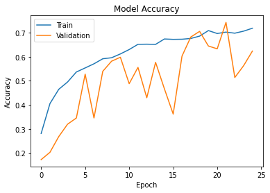

```python
plt.plot(history.history['accuracy'])
plt.plot(history.history['val_accuracy'])
plt.title('Model Accuracy')
plt.ylabel('Accuracy')
plt.xlabel('Epoch')
plt.legend(['Train', 'Validation'], loc='upper left')
plt.show()
```

```python
accuracy = model.evaluate(X_test_normalized, y_test_encoded, verbose=2)
```

```
15/15 - 0s - loss: 1.3076 - accuracy: 0.6463 - 108ms/epoch - 7ms/step
```

```python
# Here we would get the output as probablities for each category
y_pred=model.predict(X_test_normalized)
```

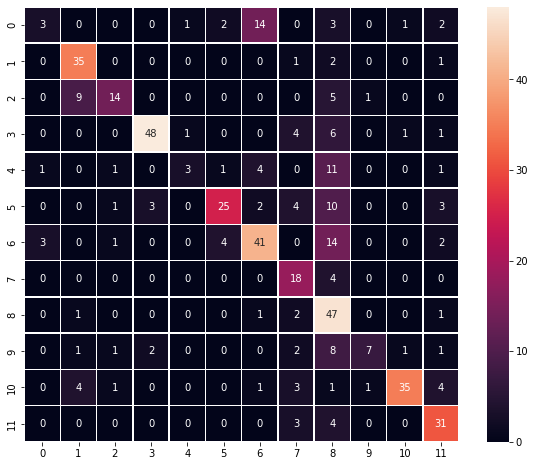

```python
# Obtaining the categorical values from y_test_encoded and y_pred
y_pred_arg=np.argmax(y_pred,axis=1)
y_test_arg=np.argmax(y_test_encoded,axis=1)

# Plotting the Confusion Matrix using confusion matrix() function which is also predefined tensorflow module
confusion_matrix = tf.math.confusion_matrix(y_test_arg,y_pred_arg)
f, ax = plt.subplots(figsize=(10, 8))
sns.heatmap(
    confusion_matrix,
    annot=True,
    linewidths=.4,
    fmt="d",
    square=True,
    ax=ax
)
plt.show()
```

```python
print(classification_report((y_test_arg), y_pred_arg))
```

```
              precision    recall  f1-score   support

           0       0.43      0.12      0.18        26
           1       0.70      0.90      0.79        39
           2       0.74      0.48      0.58        29
           3       0.91      0.79      0.84        61
           4       0.60      0.14      0.22        22
           5       0.78      0.52      0.62        48
           6       0.65      0.63      0.64        65
           7       0.49      0.82      0.61        22
           8       0.41      0.90      0.56        52
           9       0.78      0.30      0.44        23
          10       0.92      0.70      0.80        50
          11       0.66      0.82      0.73        38

    accuracy                           0.65       475
   macro avg       0.67      0.59      0.58       475
weighted avg       0.69      0.65      0.63       475
```

**Observation:**

- The confusion matrix has improved as well, however there is still some confusion with the 0 and 6 classes.
- The 0th class is the most confused class among all.
- We can observe that this model has outperformed our previous model.

# Transfer Learning using VGG16

- Let's try again, but this time, we will be using the idea of **Transfer Learning**. We will be loading a pre-built architecture - **VGG16**, which was trained on the ImageNet dataset and is the runner-up in the ImageNet competition in 2014.
- For training VGG16, we will directly use the convolutional and pooling layers and freeze their weights i.e. no training will be done on them. For classification, we will replace the existing fully-connected layers with FC layers created specifically for our problem.

```python
# Clearing backend
backend.clear_session()

# Fixing the seed for random number generators
np.random.seed(1)
random.seed(1)
tf.random.set_seed(1)
```

```python
vgg_model = VGG16(weights='imagenet', include_top = False, input_shape = (64,64,3))
vgg_model.summary()
```

```
Model: "vgg16"
_________________________________________________________________
 Layer (type)                Output Shape              Param #
=================================================================
 input_1 (InputLayer)        [(None, 64, 64, 3)]       0

 block1_conv1 (Conv2D)       (None, 64, 64, 64)        1792

 block1_conv2 (Conv2D)       (None, 64, 64, 64)        36928

 block1_pool (MaxPooling2D)  (None, 32, 32, 64)        0

 block2_conv1 (Conv2D)       (None, 32, 32, 128)       73856

 block2_conv2 (Conv2D)       (None, 32, 32, 128)       147584

 block2_pool (MaxPooling2D)  (None, 16, 16, 128)       0

 block3_conv1 (Conv2D)       (None, 16, 16, 256)       295168

 block3_conv2 (Conv2D)       (None, 16, 16, 256)       590080

 block3_conv3 (Conv2D)       (None, 16, 16, 256)       590080

 block3_pool (MaxPooling2D)  (None, 8, 8, 256)         0

 block4_conv1 (Conv2D)       (None, 8, 8, 512)         1180160

 block4_conv2 (Conv2D)       (None, 8, 8, 512)         2359808

 block4_conv3 (Conv2D)       (None, 8, 8, 512)         2359808

 block4_pool (MaxPooling2D)  (None, 4, 4, 512)         0

 block5_conv1 (Conv2D)       (None, 4, 4, 512)         2359808

 block5_conv2 (Conv2D)       (None, 4, 4, 512)         2359808

 block5_conv3 (Conv2D)       (None, 4, 4, 512)         2359808

 block5_pool (MaxPooling2D)  (None, 2, 2, 512)         0

=================================================================
Total params: 14,714,688
Trainable params: 14,714,688
Non-trainable params: 0
_________________________________________________________________
```

```python
# Making all the layers of the VGG model non-trainable. i.e. freezing them
for layer in vgg_model.layers:
    layer.trainable = False
```

```python
new_model = Sequential()

# Adding the convolutional part of the VGG16 model from above
new_model.add(vgg_model)

# Flattening the output of the VGG16 model because it is from a convolutional layer
new_model.add(Flatten())

# Adding a dense output layer
new_model.add(Dense(32, activation='relu'))
new_model.add(Dropout(0.2))
new_model.add(Dense(16, activation='relu'))
new_model.add(Dense(12, activation='softmax'))
opt=Adam()
# Compile model
new_model.compile(optimizer=opt, loss='categorical_crossentropy', metrics=['accuracy'])

# Generating the summary of the model
new_model.summary()
```

```
Model: "sequential"
_________________________________________________________________
 Layer (type)                Output Shape              Param #
=================================================================
 vgg16 (Functional)          (None, 2, 2, 512)         14714688

 flatten (Flatten)           (None, 2048)              0

 dense (Dense)               (None, 32)                65568

 dropout (Dropout)           (None, 32)                0

 dense_1 (Dense)             (None, 16)                528

 dense_2 (Dense)             (None, 12)                204

=================================================================
Total params: 14,780,988
Trainable params: 66,300
Non-trainable params: 14,714,688
_________________________________________________________________
```

```python
# Epochs
epochs = 25
# Batch size
batch_size = 64

history_vgg16 = new_model.fit(train_datagen.flow(X_train_normalized,y_train_encoded,
                                       batch_size=batch_size,
                                       seed=1,
                                       shuffle=False),
                    epochs=epochs,
                    steps_per_epoch=X_train_normalized.shape[0] // batch_size,
                    validation_data=(X_val_normalized,y_val_encoded),
                    verbose=1)
```

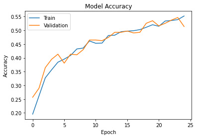

```python
plt.plot(history_vgg16.history['accuracy'])
plt.plot(history_vgg16.history['val_accuracy'])
plt.title('Model Accuracy')
plt.ylabel('Accuracy')
plt.xlabel('Epoch')
plt.legend(['Train', 'Validation'], loc='upper left')
plt.show()
```

```python
accuracy = new_model.evaluate(X_test_normalized, y_test_encoded, verbose=2)
```

```
15/15 - 0s - loss: 1.3184 - accuracy: 0.5558 - 300ms/epoch - 20ms/step
```

- The accuracy has decreased! Transfer learning saves training time and removes the need for good training dataset. However, it does not guarantee an improved accuracy.

[figure not shown]

```python
# Obtaining the categorical values from y_test_encoded and y_pred
y_pred_arg=np.argmax(y_pred,axis=1)
y_test_arg=np.argmax(y_test_encoded,axis=1)

# Plotting the Confusion Matrix using confusion matrix() function which is also predefined tensorflow module
confusion_matrix = tf.math.confusion_matrix(y_test_arg,y_pred_arg)
f, ax = plt.subplots(figsize=(10, 8))
sns.heatmap(
    confusion_matrix,
    annot=True,
    linewidths=.4,
    fmt="d",
    square=True,
    ax=ax
)
plt.show()
```

```python
print(classification_report((y_test_arg), y_pred_arg))
```

[output not shown]

# Model-5

We will try with a deeper network and see if it performs better.

```python
# Clearing backend
backend.clear_session()

# Fixing the seed for random number generators
np.random.seed(1)
random.seed(1)
tf.random.set_seed(1)
```

```python
# Intializing a sequential model
model = Sequential()

# Adding first conv layer with 64 filters and kernel size 3x3 , padding 'same' provides the output size same as the input size
# Input_shape denotes input image dimension of MNIST images
model.add(Conv2D(64, (3, 3), activation='relu', padding="same", input_shape=(64, 64, 3)))

# Adding max pooling to reduce the size of output of first conv layer
model.add(MaxPooling2D((2, 2), padding = 'same'))
model.add(BatchNormalization())

model.add(Conv2D(32, (3, 3), activation='relu', padding="same"))
model.add(MaxPooling2D((2, 2), padding = 'same'))
model.add(Conv2D(32, (3, 3), activation='relu', padding="same"))
model.add(MaxPooling2D((2, 2), padding = 'same'))
model.add(BatchNormalization())

# flattening the output of the conv layer after max pooling to make it ready for creating dense connections
model.add(Flatten())

# Adding a fully connected dense layer with 100 neurons
model.add(Dense(100, activation='relu'))
model.add(Dropout(0.3))

# Adding the output layer with 10 neurons and activation functions as softmax since this is a multi-class classification problem
model.add(Dense(12, activation='softmax'))

# Using SGD Optimizer
#opt = SGD(learning_rate=0.01, momentum=0.9)
opt=Adam()
# Compile model
model.compile(optimizer=opt, loss='categorical_crossentropy', metrics=['accuracy'])

# Generating the summary of the model
model.summary()
```

```
Model: "sequential"
_________________________________________________________________
 Layer (type)                Output Shape              Param #
=================================================================
 conv2d (Conv2D)             (None, 64, 64, 64)        1792

 max_pooling2d (MaxPooling2D  (None, 32, 32, 64)       0
 )

 batch_normalization (BatchN  (None, 32, 32, 64)       256
 ormalization)

 conv2d_1 (Conv2D)           (None, 32, 32, 32)        18464

 max_pooling2d_1 (MaxPooling  (None, 16, 16, 32)       0
 2D)

 conv2d_2 (Conv2D)           (None, 16, 16, 32)        9248

 max_pooling2d_2 (MaxPooling  (None, 8, 8, 32)         0
 2D)

 batch_normalization_1 (Batc  (None, 8, 8, 32)         128
 hNormalization)

 flatten (Flatten)           (None, 2048)              0

 dense (Dense)               (None, 100)               204900

 dropout (Dropout)           (None, 100)               0

 dense_1 (Dense)             (None, 12)                1212

=================================================================
Total params: 236,000
Trainable params: 235,808
Non-trainable params: 192
_________________________________________________________________
```

```python
# Epochs
epochs = 25
# Batch size
batch_size = 64

history = model.fit(train_datagen.flow(X_train_normalized,y_train_encoded,
                                       batch_size=batch_size,
                                       seed=1,
                                       shuffle=False),
                    epochs=epochs,
                    steps_per_epoch=X_train_normalized.shape[0] // batch_size,
                    validation_data=(X_val_normalized,y_val_encoded),
                    verbose=1)
```

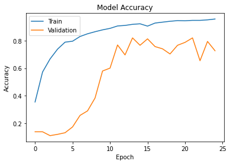

```python
plt.plot(history.history['accuracy'])
plt.plot(history.history['val_accuracy'])
plt.title('Model Accuracy')
plt.ylabel('Accuracy')
plt.xlabel('Epoch')
plt.legend(['Train', 'Validation'], loc='upper left')
plt.show()
```

```python
accuracy = model.evaluate(X_test_normalized, y_test_encoded, verbose=2)
```

```
15/15 - 0s - loss: 1.2665 - accuracy: 0.6989 - 77ms/epoch - 5ms/step
```

We can observe that our accuracy has improved compared to our previous best model. This was achieved by having a deeper network with data augmentation AND Batch normalization.

```python
# Here we would get the output as probablities for each category
y_pred=model.predict(X_test_normalized)
```

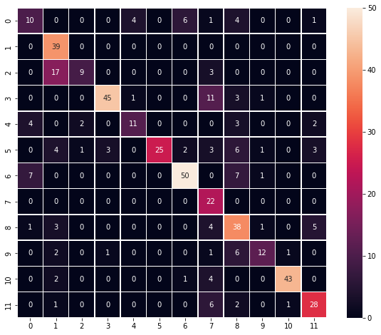

```python
# Obtaining the categorical values from y_test_encoded and y_pred
y_pred_arg=np.argmax(y_pred,axis=1)
y_test_arg=np.argmax(y_test_encoded,axis=1)

# Plotting the Confusion Matrix using confusion matrix() function which is also predefined tensorflow module
confusion_matrix = tf.math.confusion_matrix(y_test_arg,y_pred_arg)
f, ax = plt.subplots(figsize=(10, 8))
sns.heatmap(
    confusion_matrix,
    annot=True,
    linewidths=.4,
    fmt="d",
    square=True,
    ax=ax
)
plt.show()
```

```python
print(classification_report((y_test_arg), y_pred_arg))
```

```
              precision    recall  f1-score   support

           0       0.45      0.38      0.42        26
           1       0.57      1.00      0.73        39
           2       0.75      0.31      0.44        29
           3       0.92      0.74      0.82        61
           4       0.69      0.50      0.58        22
           5       1.00      0.52      0.68        48
           6       0.85      0.77      0.81        65
           7       0.40      1.00      0.57        22
           8       0.55      0.73      0.63        52
           9       0.75      0.52      0.62        23
          10       0.96      0.86      0.91        50
          11       0.72      0.74      0.73        38

    accuracy                           0.70       475
   macro avg       0.72      0.67      0.66       475
weighted avg       0.76      0.70      0.70       475
```

**Observation:**

# Model-6

We will try with class weights and see if it improves performance.

```python
# Clearing backend
backend.clear_session()

# Fixing the seed for random number generators
np.random.seed(1)
random.seed(1)
tf.random.set_seed(1)
```

```python
# Intializing a sequential model
model = Sequential()

# Adding first conv layer with 64 filters and kernel size 3x3 , padding 'same' provides the output size same as the input size
# Input_shape denotes input image dimension of MNIST images
model.add(Conv2D(64, (3, 3), activation='relu', padding="same", input_shape=(64, 64, 3)))

# Adding max pooling to reduce the size of output of first conv layer
model.add(MaxPooling2D((2, 2), padding = 'same'))
model.add(BatchNormalization())

model.add(Conv2D(32, (3, 3), activation='relu', padding="same"))
model.add(MaxPooling2D((2, 2), padding = 'same'))
model.add(Conv2D(32, (3, 3), activation='relu', padding="same"))
model.add(MaxPooling2D((2, 2), padding = 'same'))
model.add(BatchNormalization())

# flattening the output of the conv layer after max pooling to make it ready for creating dense connections
model.add(Flatten())

# Adding a fully connected dense layer with 100 neurons
model.add(Dense(100, activation='relu'))
model.add(Dropout(0.3))

# Adding the output layer with 10 neurons and activation functions as softmax since this is a multi-class classification problem
model.add(Dense(12, activation='softmax'))

# Using SGD Optimizer
#opt = SGD(learning_rate=0.01, momentum=0.9)
opt=Adam()
# Compile model
model.compile(optimizer=opt, loss='categorical_crossentropy', metrics=['accuracy'])

# Generating the summary of the model
model.summary()
```

```
Model: "sequential"
_________________________________________________________________
 Layer (type)                Output Shape              Param #
=================================================================
 conv2d (Conv2D)             (None, 64, 64, 64)        1792

 max_pooling2d (MaxPooling2D  (None, 32, 32, 64)       0
 )

 batch_normalization (BatchN  (None, 32, 32, 64)       256
 ormalization)

 conv2d_1 (Conv2D)           (None, 32, 32, 32)        18464

 max_pooling2d_1 (MaxPooling  (None, 16, 16, 32)       0
 2D)

 conv2d_2 (Conv2D)           (None, 16, 16, 32)        9248

 max_pooling2d_2 (MaxPooling  (None, 8, 8, 32)         0
 2D)

 batch_normalization_1 (Batc  (None, 8, 8, 32)         128
 hNormalization)

 flatten (Flatten)           (None, 2048)              0

 dense (Dense)               (None, 100)               204900

 dropout (Dropout)           (None, 100)               0

 dense_1 (Dense)             (None, 12)                1212

=================================================================
Total params: 236,000
Trainable params: 235,808
Non-trainable params: 192
_________________________________________________________________
```

```python
# Epochs
epochs = 25
# Batch size
batch_size = 64

history = model.fit(train_datagen.flow(X_train_normalized,y_train_encoded,
                                       batch_size=batch_size,
                                       seed=1,
                                       shuffle=False),
                    epochs=epochs,
                    class_weight=class_weights,
                    steps_per_epoch=X_train_normalized.shape[0] // batch_size,
                    validation_data=(X_val_normalized,y_val_encoded),
                    verbose=1)
```

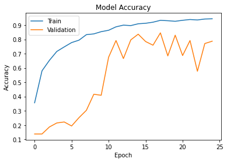

```python
plt.plot(history.history['accuracy'])
plt.plot(history.history['val_accuracy'])
plt.title('Model Accuracy')
plt.ylabel('Accuracy')
plt.xlabel('Epoch')
plt.legend(['Train', 'Validation'], loc='upper left')
plt.show()
```

```python
accuracy = model.evaluate(X_test_normalized, y_test_encoded, verbose=2)
```

```
15/15 - 0s - loss: 1.1683 - accuracy: 0.7811 - 71ms/epoch - 5ms/step
```

We can observe that our accuracy has improved compared to our previous best model. This was achieved by factoring in the class imbalance and having a deeper network with data augmentation AND Batch normalization.

```python
# Here we would get the output as probablities for each category
y_pred=model.predict(X_test_normalized)
```

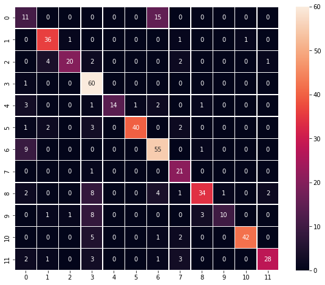

```python
# Obtaining the categorical values from y_test_encoded and y_pred
y_pred_arg=np.argmax(y_pred,axis=1)
y_test_arg=np.argmax(y_test_encoded,axis=1)

# Plotting the Confusion Matrix using confusion matrix() function which is also predefined tensorflow module
confusion_matrix = tf.math.confusion_matrix(y_test_arg,y_pred_arg)
f, ax = plt.subplots(figsize=(10, 8))
sns.heatmap(
    confusion_matrix,
    annot=True,
    linewidths=.4,
    fmt="d",
    square=True,
    ax=ax
)
plt.show()
```

```python
print(classification_report((y_test_arg), y_pred_arg))
```

```
              precision    recall  f1-score   support

           0       0.38      0.42      0.40        26
           1       0.82      0.92      0.87        39
           2       0.91      0.69      0.78        29
           3       0.66      0.98      0.79        61
           4       1.00      0.64      0.78        22
           5       0.98      0.83      0.90        48
           6       0.71      0.85      0.77        65
           7       0.66      0.95      0.78        22
           8       0.87      0.65      0.75        52
           9       0.91      0.43      0.59        23
          10       0.98      0.84      0.90        50
          11       0.90      0.74      0.81        38

    accuracy                           0.78       475
   macro avg       0.81      0.75      0.76       475
weighted avg       0.81      0.78      0.78       475
```

**Observation:**

- The confusion matrix has improved as well, however there is still some confusion with the 0 and 6 classes.
- The 0th class is the most confused class among all.
- We can observe that this model has outperformed our previous best model by 8%.

## **Visualizing the prediction:**

- Let's view a few cases from the latest model and compare the predicted class with the label.

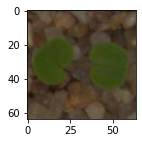

```
Predicted Label ['Small-flowered Cranesbill']
True Label Small-flowered Cranesbill
```

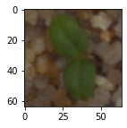

```
Predicted Label ['Cleavers']
True Label Cleavers
```

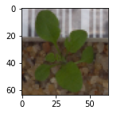

```
Predicted Label ['Shepherds Purse']
True Label Shepherds Purse
```

```python
# Visualizing the predicted and correct label of images from test data
plt.figure(figsize=(2,2))
plt.imshow(X_test[2])
plt.show()
print('Predicted Label', enc.inverse_transform(model.predict((X_test_normalized[2].reshape(1,64,64,3)))))   # reshaping the input image as we are only trying to predict using a single image
print('True Label', enc.inverse_transform(y_test_encoded)[2])                                               # using inverse_transform() to get the output label from the output vector

plt.figure(figsize=(2,2))
plt.imshow(X_test[33])
plt.show()
print('Predicted Label', enc.inverse_transform(model.predict((X_test_normalized[33].reshape(1,64,64,3)))))  # reshaping the input image as we are only trying to predict using a single image
print('True Label', enc.inverse_transform(y_test_encoded)[33])                                              # using inverse_transform() to get the output label from the output vector

plt.figure(figsize=(2,2))
plt.imshow(X_test[36])
plt.show()
print('Predicted Label', enc.inverse_transform(model.predict((X_test_normalized[36].reshape(1,64,64,3)))))  # reshaping the input image as we are only trying to predict using a single image
print('True Label', enc.inverse_transform(y_test_encoded)[36])                                              # using inverse_transform() to get the output label from the output vector
```

- These were all correct predictions. Let's look at a few misclassifications (classes 0 and 6)

```
Image # 34
```

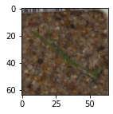

```
Predicted Label ['Loose Silky-bent']
True Label Black-grass

Image # 40
```

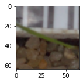

```
Predicted Label ['Loose Silky-bent']
True Label Black-grass

Image # 52
```

[figure not shown]

```
Predicted Label ['Loose Silky-bent']
True Label Black-grass

Image # 91
```

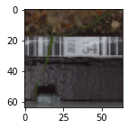

```
Predicted Label ['Black-grass']
True Label Loose Silky-bent

Image # 100
```

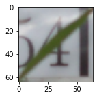

```
Predicted Label ['Black-grass']
True Label Loose Silky-bent
```

```python
myiter = 0
casesShown = 0
while(casesShown<5): # we will look at 5 mis classified images
  if((y_pred_arg[myiter] == 0 and y_test_arg[myiter] == 6) or ((y_pred_arg[myiter] == 6 and y_test_arg[myiter] == 0))):
    print("Image #",myiter)
    plt.figure(figsize=(2,2))
    plt.imshow(X_test[myiter])
    plt.show()
    print('Predicted Label', enc.inverse_transform(model.predict((X_test_normalized[myiter].reshape(1,64,64,3)))))   # reshaping the input image as we are only trying to predict using a single image
    print('True Label', enc.inverse_transform(y_test_encoded)[myiter])                                               # using inverse_transform() to get the output label from the output vector
    print("")
    casesShown = casesShown + 1
  myiter = myiter + 1
```

## Results Summary

```python
pd.DataFrame({'Models':['Base CNN Model','CNN Model with Data Augmentation','With Batch Normalization and Dropout','Transfer Learning Model','With Deeper network','With class balancing'],
              'Train Accuracy':['92%','71%','72%','55%','96%','94%'],'Validation Accuracy':['61%','62%','62%','51%','73%','79%'],'Test Accuracy':['62%','62%','65%','56%','70%','78%']
              })
```

|  | Models | Train Accuracy | Validation Accuracy | Test Accuracy |
| --- | --- | --- | --- | --- |
| 0 | Base CNN Model | 92% | 61% | 62% |
| 1 | CNN Model with Data Augmentation | 71% | 62% | 62% |
| 2 | With Batch Normalization and Dropout | 72% | 62% | 65% |
| 3 | Transfer Learning Model | 55% | 51% | 56% |
| 4 | With Deeper network | 96% | 73% | 70% |
| 5 | With class balancing | 94% | 79% | 78% |